# Unsupervised Learning

M.Erim Çelen

02 2020

## K Means Clustering

Loading Data

We will be load the glass data.

```r
data <- read.csv("glass.csv")
data <- data[,-10]
# I am deleting variables because it's labeled.
```

```r
head(data)
```

```
##        RI    Na   Mg   Al    Si    K   Ca Ba   Fe
## 1 1.52101 13.64 4.49 1.10 71.78 0.06 8.75  0 0.00
## 2 1.51761 13.89 3.60 1.36 72.73 0.48 7.83  0 0.00
## 3 1.51618 13.53 3.55 1.54 72.99 0.39 7.78  0 0.00
## 4 1.51766 13.21 3.69 1.29 72.61 0.57 8.22  0 0.00
## 5 1.51742 13.27 3.62 1.24 73.08 0.55 8.07  0 0.00
## 6 1.51596 12.79 3.61 1.62 72.97 0.64 8.07  0 0.26
```

Data Analysis

Firstly, I would like to demonstrate an overview of the individual data sets using the summary and str function.

```r
summary(data)
```

```
##        RI              Na              Mg              Al
##  Min.   :1.511   Min.   :10.73   Min.   :0.000   Min.   :0.290
##  1st Qu.:1.517   1st Qu.:12.91   1st Qu.:2.115   1st Qu.:1.190
##  Median :1.518   Median :13.30   Median :3.480   Median :1.360
##  Mean   :1.518   Mean   :13.41   Mean   :2.685   Mean   :1.445
##  3rd Qu.:1.519   3rd Qu.:13.82   3rd Qu.:3.600   3rd Qu.:1.630
##  Max.   :1.534   Max.   :17.38   Max.   :4.490   Max.   :3.500
##        Si              K                Ca               Ba
##  Min.   :69.81   Min.   :0.0000   Min.   : 5.430   Min.   :0.000
##  1st Qu.:72.28   1st Qu.:0.1225   1st Qu.: 8.240   1st Qu.:0.000
##  Median :72.79   Median :0.5550   Median : 8.600   Median :0.000
##  Mean   :72.65   Mean   :0.4971   Mean   : 8.957   Mean   :0.175
##  3rd Qu.:73.09   3rd Qu.:0.6100   3rd Qu.: 9.172   3rd Qu.:0.000
##  Max.   :75.41   Max.   :6.2100   Max.   :16.190   Max.   :3.150
##        Fe
##  Min.   :0.00000
##  1st Qu.:0.00000
##  Median :0.00000
##  Mean   :0.05701
##  3rd Qu.:0.10000
##  Max.   :0.51000
```

```r
str(data)
```

```
## 'data.frame':    214 obs. of  9 variables:
##  $ RI: num  1.52 1.52 1.52 1.52 1.52 ...
##  $ Na: num  13.6 13.9 13.5 13.2 13.3 ...
##  $ Mg: num  4.49 3.6 3.55 3.69 3.62 3.61 3.6 3.61 3.58 3.6 ...
##  $ Al: num  1.1 1.36 1.54 1.29 1.24 1.62 1.14 1.05 1.37 1.36 ...
##  $ Si: num  71.8 72.7 73 72.6 73.1 ...
##  $ K : num  0.06 0.48 0.39 0.57 0.55 0.64 0.58 0.57 0.56 0.57 ...
##  $ Ca: num  8.75 7.83 7.78 8.22 8.07 8.07 8.17 8.24 8.3 8.4 ...
##  $ Ba: num  0 0 0 0 0 0 0 0 0 0 ...
##  $ Fe: num  0 0 0 0 0 0.26 0 0 0 0.11 ...
```

We can see that the all the variables are numeric so that, we can use these variables for cluster analysis. However, it is better the use only the relevant variable for the Cluster analysis.

In order to see more visualized data we plot the histogram of each element.

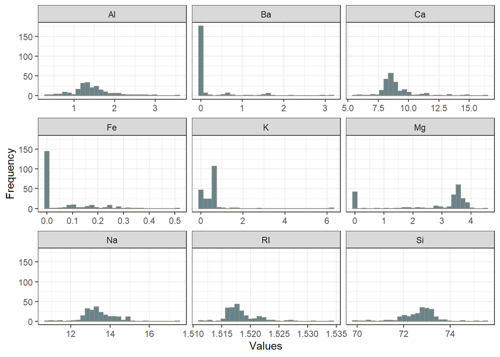

To understand the relationships between each elements I build correlation matrix.

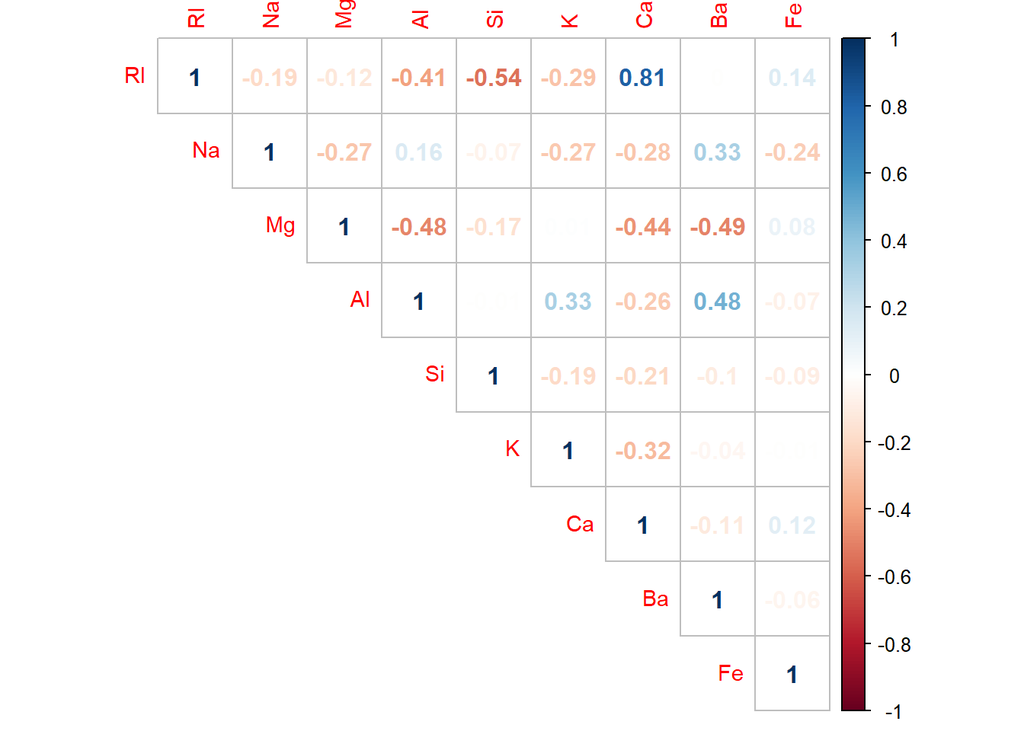

```r
corrplot(cor(data), type = 'upper', method = 'number', tl.cex = 0.9)
```

A strong relationship between RI and Ca was seen. I will create a model to show the relationship between these variables by fitting a linear equation.

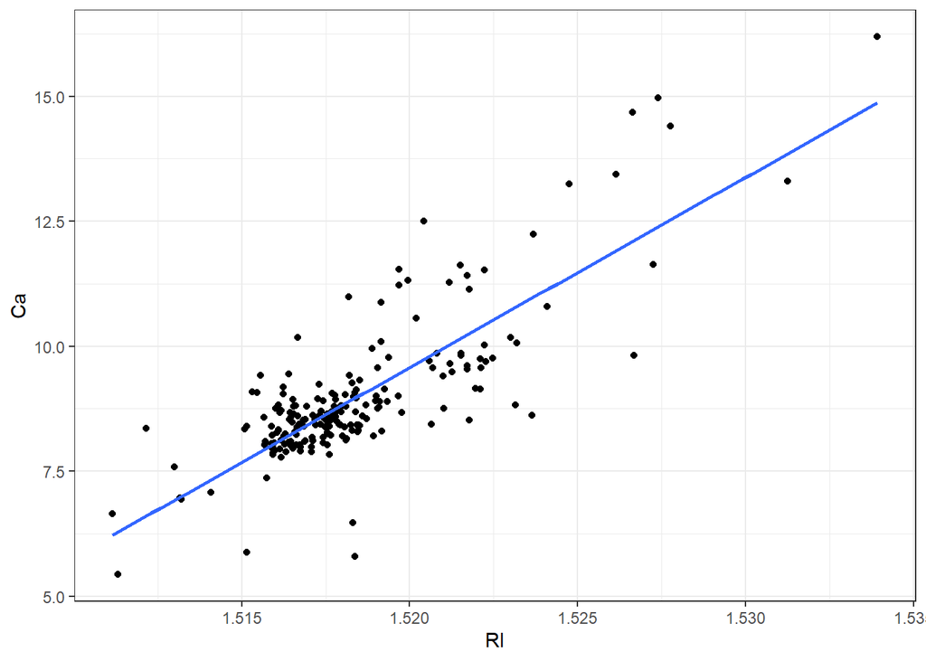

```r
ggplot(data, aes(x = RI, y= Ca)) +
  geom_point() +
  geom_smooth(method = 'lm', se = FALSE) +
  theme_bw()
```

In order to prepare our data for clustering, we need our data to be scaled. We can scale our data by standard deviation and mean and also using scale function.

```r
dataNorm <- as.data.frame(scale(data))
head(dataNorm)
```

```
##           RI         Na        Mg         Al          Si           K         Ca
## 1  0.8708258  0.2842867 1.2517037 -0.6908222 -1.12444556 -0.67013422 -0.1454254
## 2 -0.2487502  0.5904328 0.6346799 -0.1700615  0.10207972 -0.02615193 -0.7918771
## 3 -0.7196308  0.1495824 0.6000157  0.1904651  0.43776033 -0.16414813 -0.8270103
## 4 -0.2322859 -0.2422846 0.6970756 -0.3102663 -0.05284979  0.11184428 -0.5178378
## 5 -0.3113148 -0.1688095 0.6485456 -0.4104126  0.55395746  0.08117845 -0.6232375
## 6 -0.7920739 -0.7566101 0.6416128  0.3506992  0.41193874  0.21917466 -0.6232375
##           Ba         Fe
## 1 -0.3520514 -0.5850791
## 2 -0.3520514 -0.5850791
## 3 -0.3520514 -0.5850791
## 4 -0.3520514 -0.5850791
## 5 -0.3520514 -0.5850791
## 6 -0.3520514  2.0832652
```

Computing k-means clustering in R We use eclust function from the factoextra package to compute k means clustering with two clusters(k=2) by euclidean metric.

The following code shows the cluster we created.

```r
data_cluster <- eclust(dataNorm, "kmeans", hc_metric="euclidean",k=2)
```

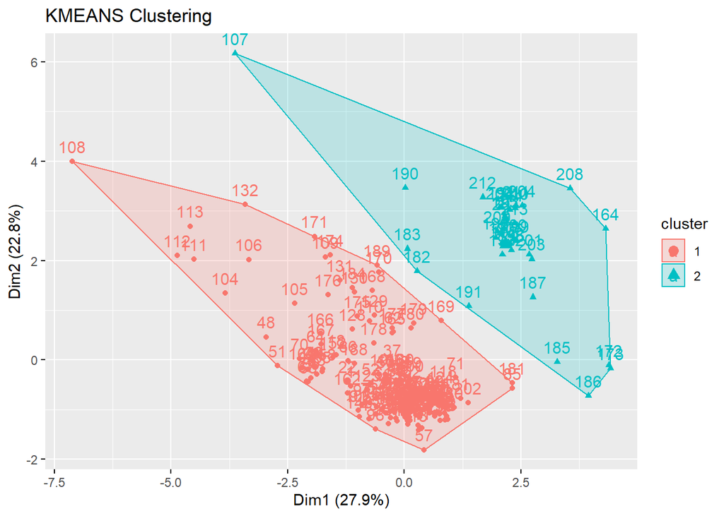

```r
attributes(data_cluster)
```

```
## $names
##  [1] "cluster"      "centers"      "totss"        "withinss"     "tot.withinss"
##  [6] "betweenss"    "size"         "iter"         "ifault"       "clust_plot"
## [11] "silinfo"      "nbclust"      "data"
##
## $class
## [1] "kmeans" "eclust"
```

```r
data_cluster$cluster
```

```
##   [1] 1 1 1 1 1 1 1 1 1 1 1 1 1 1 1 1 1 1 1 1 1 1 1 1 1 1 1 1 1 1 1 1 1 1 1 1 1
##  [38] 1 1 1 1 1 1 1 1 1 1 1 1 1 1 1 1 1 1 1 1 1 1 1 1 1 1 1 1 1 1 1 1 1 1 1 1 1
##  [75] 1 1 1 1 1 1 1 1 1 1 1 1 1 1 1 1 1 1 1 1 1 1 1 1 1 1 1 1 1 1 1 1 2 1 1 1 1
## [112] 1 1 1 1 1 1 1 1 1 1 1 1 1 1 1 1 1 1 1 1 1 1 1 1 1 1 1 1 1 1 1 1 1 1 1 1 1
## [149] 1 1 1 1 1 1 1 1 1 1 1 1 1 1 1 2 1 1 1 1 1 1 1 2 2 1 1 1 1 1 1 1 1 2 2 1 2
## [186] 2 2 1 1 2 2 2 2 2 2 2 2 2 2 2 2 1 2 2 2 2 2 2 2 2 2 2 2 2
```

```r
data_cluster$centers
```

```
##            RI         Na         Mg         Al          Si           K
## 1  0.09076112 -0.2259117  0.2875011 -0.2791711 -0.01597200 -0.03089581
## 2 -0.49781101  1.2390915 -1.5768998  1.5312114  0.08760399  0.16945885
##            Ca         Ba          Fe
## 1  0.06331658 -0.3303839  0.06868228
## 2 -0.34728183  1.8121057 -0.37671187
```

```r
data_cluster$size
```

```
## [1] 181  33
```

```r
data_cluster$betweenss
```

```
## [1] 397.8528
```

```r
data_cluster$withinss
```

```
## [1] 988.3260 530.8212
```

```r
data_cluster$totss
```

```
## [1] 1917
```

Since the k values should be set beforehand, it’s advisable to have different k values. It gives us different outcomes to analyize.

```r
data_cluster3 <- eclust(dataNorm, "kmeans", hc_metric="euclidean",k=3)
```

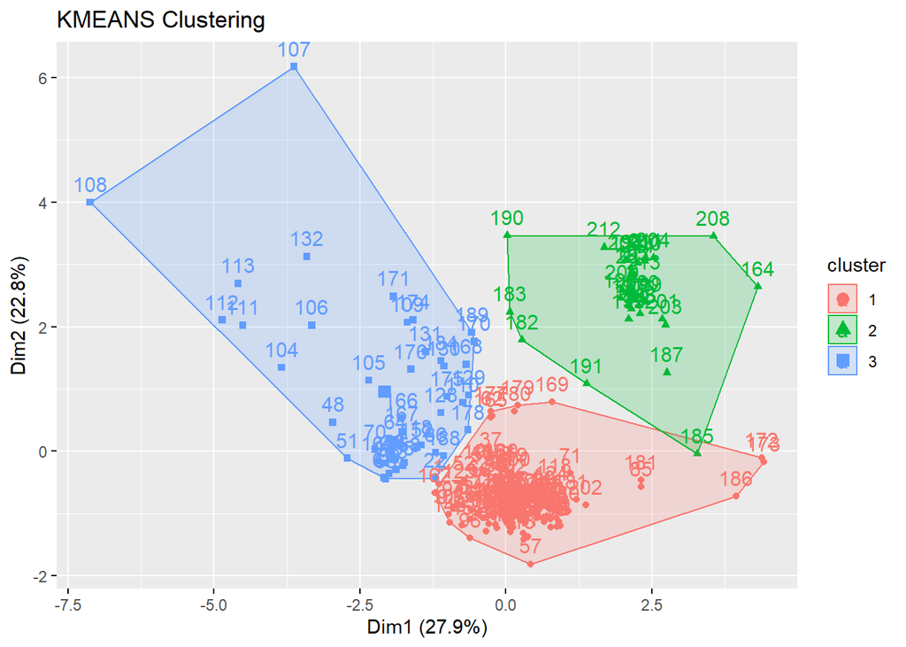

```r
data_cluster4 <- eclust(dataNorm, "kmeans", hc_metric="euclidean",k=4)
```

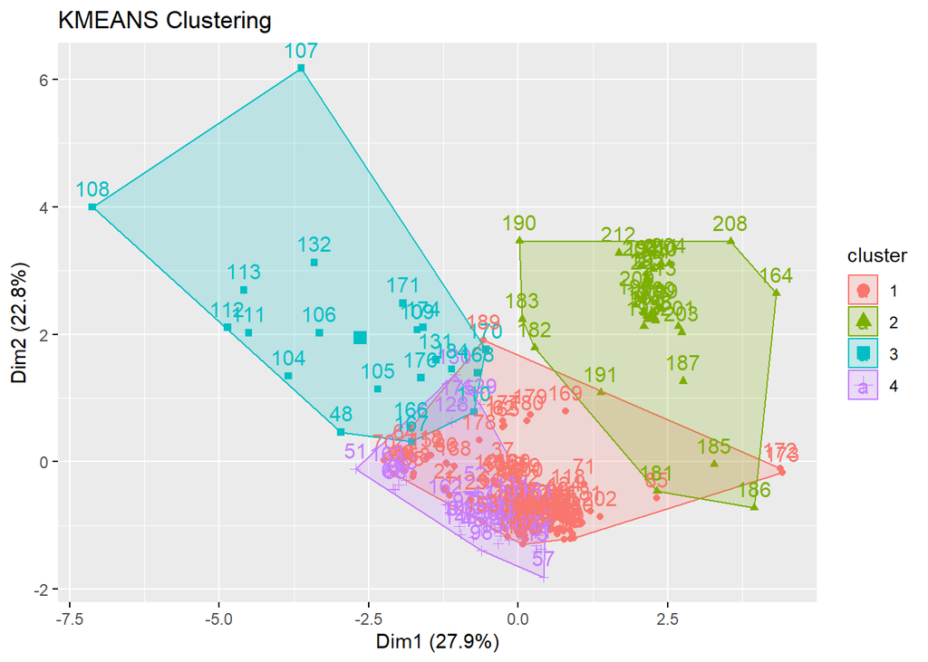

```r
data_cluster5 <- eclust(dataNorm, "kmeans", hc_metric="euclidean",k=5)
```

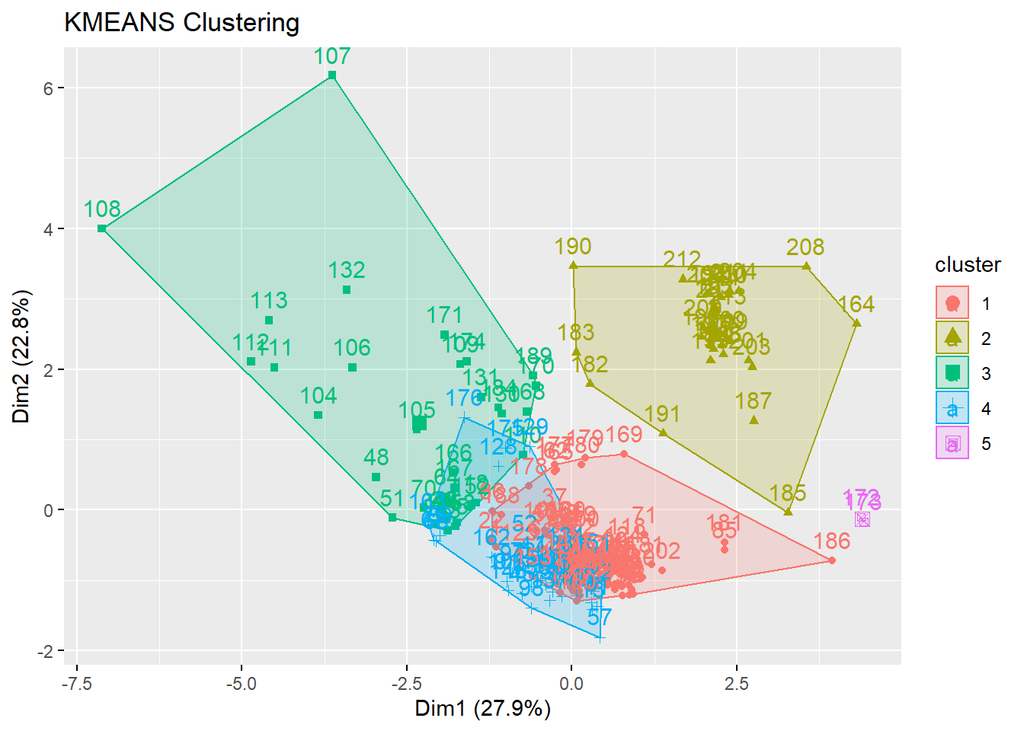

Finding Optimal Clusters

We are going to use 3 approaches in order to find the optimal number of clusters.

First we calculated the Elbow Method.

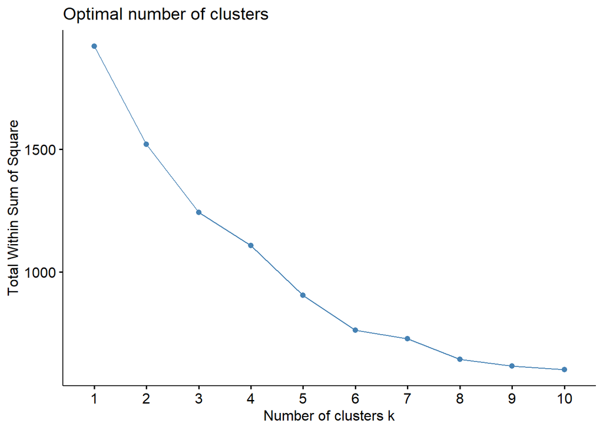

```r
fviz_nbclust(x = dataNorm,FUNcluster = kmeans, method = 'wss' )
```

And then we continue with the Silhouette Method.

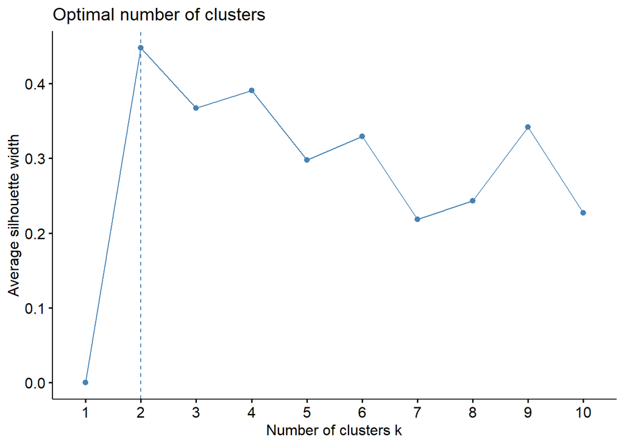

```r
fviz_nbclust(x = dataNorm,FUNcluster = kmeans, method = 'silhouette' )
```

Lastly we will use the method call Gap-static in order find optimal value of k.

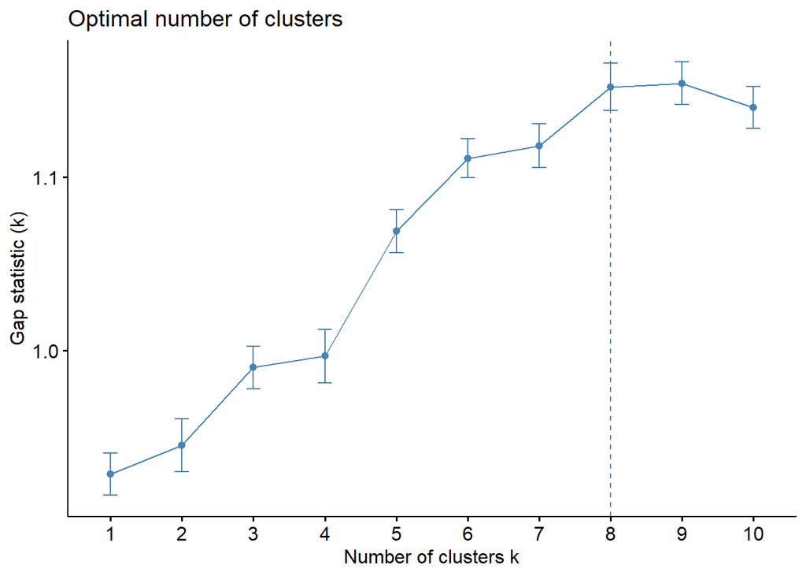

```r
fviz_nbclust(x = dataNorm,FUNcluster = kmeans, method = 'gap_stat' )
```

We can also Automaticly select the number of clusters by using pamk function.

```r
pamk.best<-pamk(dataNorm, krange=2:10,criterion="asw", usepam=TRUE, scaling=FALSE, alpha=0.001, diss=inherits(dataNorm, "dist"), critout=FALSE)
class(pamk.best)
```

```
## [1] "list"
```

```r
pamk.best
```

```
## $pamobject
## Medoids:
##       ID         RI         Na        Mg         Al        Si          K
## [1,]  43 -0.1894786 -0.2422846  0.489090 -0.2301493 0.1408121  0.1425101
## [2,] 198 -0.3607078  1.5823462 -1.861147  1.7928057 0.8121733 -0.7621317
##                Ca         Ba         Fe
## [1,] -0.257851750 -0.3520514 -0.5850791
## [2,] -0.004892386  0.9753308 -0.5850791
## Clustering vector:
##   [1] 1 1 1 1 1 1 1 1 1 1 1 1 1 1 1 1 1 1 1 1 1 1 1 1 1 1 1 1 1 1 1 1 1 1 1 1 1
##  [38] 1 1 1 1 1 1 1 1 1 1 1 1 1 1 1 1 1 1 1 1 1 1 1 1 1 1 1 1 1 1 1 1 1 1 1 1 1
##  [75] 1 1 1 1 1 1 1 1 1 1 1 1 1 1 1 1 1 1 1 1 1 1 1 1 1 1 1 1 1 1 1 1 2 1 1 1 1
## [112] 1 1 1 1 1 1 1 1 1 1 1 1 1 1 1 1 1 1 1 1 1 1 1 1 1 1 1 1 1 1 1 1 1 1 1 1 1
## [149] 1 1 1 1 1 1 1 1 1 1 1 1 1 1 1 2 1 1 1 1 1 2 1 1 1 1 1 1 1 1 1 1 2 2 2 1 2
## [186] 1 1 1 1 2 2 2 2 2 2 2 2 2 2 2 2 1 2 2 2 2 2 2 2 2 2 2 2 2
## Objective function:
##   build    swap
## 2.17918 2.17918
##
## Available components:
##  [1] "medoids"    "id.med"     "clustering" "objective"  "isolation"
##  [6] "clusinfo"   "silinfo"    "diss"       "call"       "data"
##
## $nc
## [1] 2
##
## $crit
##  [1] 0.0000000 0.4112153 0.2501838 0.2827879 0.3019384 0.3278116 0.3235922
##  [8] 0.2881257 0.1932467 0.1992271
```

We can use the following code to visualize our results.

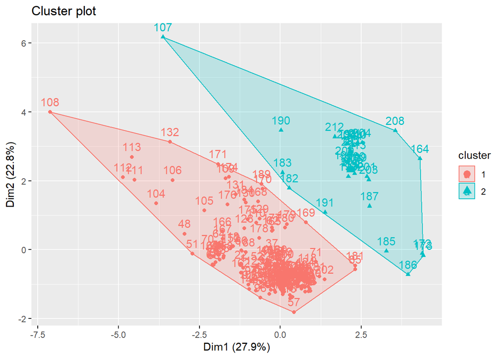

```r
fviz_cluster(data_cluster, data = dataNorm)
```

```r
dataNorm %>%
  mutate(Cluster = data_cluster$cluster) %>%
  group_by(Cluster) %>%
  summarize_all('median')
```

```
## # A tibble: 2 x 10
##   Cluster     RI     Na     Mg     Al    Si       K     Ca     Ba     Fe
##     <int>  <dbl>  <dbl>  <dbl>  <dbl> <dbl>   <dbl>  <dbl>  <dbl>  <dbl>
## 1       1 -0.173 -0.242  0.579 -0.250 0.128  0.0965 -0.251 -0.352 -0.585
## 2       2 -0.647  1.19  -1.86   1.31  0.580 -0.762  -0.244  1.28  -0.585
```